# Homophily, Tie Formation, and Tie Decay Based on Race at ND - Preliminary Data

Rocco Peri

## Inspiration

- Racial Dynamics at ND (PWI but same-race friendgroups)
- Existence of Same-Race Social Foci (FASO, AAA, BSA, VSA, etc.)
- Data sets than can allow for the study of race interactions/ties at ND (NetHealth)

## Data and Methods Used

- NetHealth Data (Wave 3 and Wave 5 representing Spring 2016 and Spring 2017)
- Dyad datasets compiled by Ethan measuring tie decay and formation between the two waves
- Tidyverse functions (select, mutate, filter, etc.) to manipulate the network data
- Generalized Linear Models function to obtain regression coefficients & percent change for tie decay and formation

# Preliminary Data

## Average Summary Statistics per Race

```r
traits_df <- read.csv(here("ego_stats_sp16 - ego_stats_sp16.csv"))

white_df <- traits_df |>
  filter(race == "White")
latino_df <- traits_df |>
  filter(race == "Latino/a")
asian_df <- traits_df |>
  filter(race == "Asian-American")
african_df <- traits_df |>
  filter(race == "African-American")
foreign_df <- traits_df |>
  filter(race == "Foreign Student")
```

## Average Summary Statistics per Race

```r
mean(white_df$egonet_clustering, na.rm = TRUE)
mean(latino_df$egonet_clustering, na.rm = TRUE)
mean(asian_df$egonet_clustering, na.rm = TRUE)
mean(african_df$egonet_clustering, na.rm = TRUE)
mean(foreign_df$egonet_clustering, na.rm = TRUE)
```

I did this above code for egonet clustering coefficient, egonet diversity iqv, and network size, over the two waves, and took the differential between the two years to get the change of these statistics overtime.

## Average Summary Statistics per Race

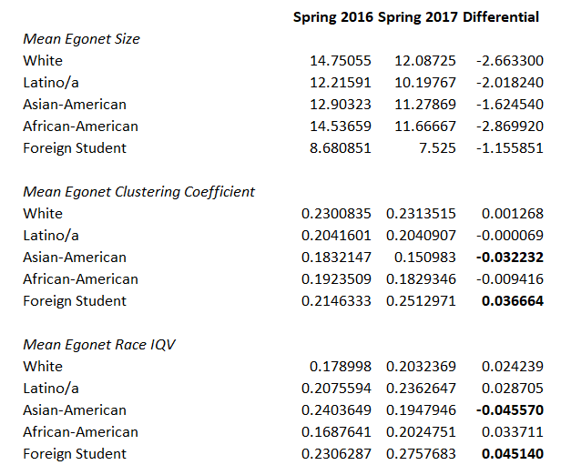

# Tie Decay

## Average Tie Decay of Same Race and Race Pair Ties

I used Ethan’s compiled data set to obtain decay data of the ties in the waves

```
# A tibble: 4,699 × 6
    ...1  from    to pair_race                     same_race decay
   <dbl> <dbl> <dbl> <chr>                         <lgl>     <lgl>
 1     1 56527 46744 Latino/a and White            FALSE     TRUE
 2     2 73158 46744 White and White               TRUE      TRUE
 3     3 43516 83005 Latino/a and White            FALSE     FALSE
 4     4 34591 31439 White and White               TRUE      TRUE
 5     5 46744 21899 White and White               TRUE      TRUE
 6     6 16819 45375 African-American and Latino/a FALSE     FALSE
 7     7 89411 24016 Latino/a and White            FALSE     TRUE
 8     8 31439 24016 White and White               TRUE      TRUE
 9     9 34591 36875 White and White               TRUE      TRUE
10    10 31439 36875 White and White               TRUE      FALSE
# ℹ 4,689 more rows
```

## Average Tie Decay of Same Race and Race Pair Ties

Then, I used this to obtain the average tie decay for same race and the different race pair ties.

```r
decay_rates_pair_race <- dyads_2016 |>
  group_by(pair_race) |>
  summarize(percent_decay = mean(decay))

decay_rates_same_race <- dyads_2016 |>
  group_by(same_race) |>
  summarize(percent_decay = mean(decay))
```

## Average Tie Decay of Race Pair Ties

```
# A tibble: 15 × 3
    ...1 pair_race                             percent_decay
   <dbl> <chr>                                         <dbl>
 1     1 African-American and African-American         0.554
 2     2 African-American and Asian-American           0.479
 3     3 African-American and Foreign Student          0.654
 4     4 African-American and Latino/a                 0.629
 5     5 African-American and White                    0.685
 6     6 Asian-American and Asian-American             0.547
 7     7 Asian-American and Foreign Student            0.594
 8     8 Asian-American and Latino/a                   0.506
 9     9 Asian-American and White                      0.557
10    10 Foreign Student and Foreign Student           0.652
11    11 Foreign Student and Latino/a                  0.617
12    12 Foreign Student and White                     0.703
13    13 Latino/a and Latino/a                         0.543
14    14 Latino/a and White                            0.617
15    15 White and White                               0.558
```

## Average Tie Decay of Same Race Ties

```
# A tibble: 2 × 3
   ...1 same_race percent_decay
  <dbl> <lgl>             <dbl>
1     1 FALSE             0.611
2     2 TRUE              0.558
```

## Tie Decay Regressions for Same Race and Race Pairs

I ran a logistic regression on tie decay likelihood with “same_race” and “race_pair” as a predictor, controlling for gender, first generation student, clustering coefficient, and egonet size using the glm function with White - White as the reference. The output is the coefficients in log likelihood, so I had to convert the coefficients to % change for interpretative purposes.

## Tie Decay Regressions for Same Race and Race Pairs

```r
#Combining the dyad data with the egonet stats data
sp16_dyads <- sp16_dyads |>
  mutate(pair_race = relevel(as.factor(pair_race), ref = "White and White"))

sp16_final_df <- sp16_dyads |>
  left_join(traits_df, by = "from")

#Logistic regression on tie decay likelihood with "same_race" as predictor controlling
#for gender, first generation student, clustering coefficient, and egonet size
decay_same_race <- glm(decay ~ same_race + male + firstgen + egonet_clustering + egonet_size,
                data = sp16_final_df, family = binomial())

#Getting the data out of log likelihood into %
(exp(coef(decay_same_race)) - 1) * 100
summary(decay_same_race)
```

## Tie Decay Regressions for Same Race

```
# A tibble: 5 × 5
   ...1 variable          percentage_change significance_of_coefs p_value
  <dbl> <chr>                         <dbl> <chr>                 <chr>
1     1 Same Race = TRUE            -14.9   **                    <.001
2     2 Male                        -19.9   ***                   ~0
3     3 First Generation             26.7   <NA>                  >.1
4     4 Egonet_Clustering           -82.2   ***                   ~0
5     5 Degree                        0.124 <NA>                  >.1
```

Interpretation: Controlling for gender, first generation student, clustering coefficient, and egonet size, When same race = TRUE, ties are ~ 15% less likely to decay with a p-value of less than .01, meaning that the coefficient is statistically significant.

## Tie Decay Regressions for Race Pairs

```
# A tibble: 14 × 5
    ...1 pair                    percentage_change significance_of_coefs p_value
   <dbl> <chr>                               <dbl> <chr>                 <chr>
 1     1 African-American and A…            -19.2  <NA>                  >.1
 2     2 African-American and A…            -36.2  <NA>                  >.1
 3     3 African-American and F…             19.3  <NA>                  >.1
 4     4 African-American and L…             15.2  <NA>                  >.1
 5     5 African-American and W…             63.1  ***                   ~0
 6     6 Asian-American and Asi…            -10.7  <NA>                  >.1
 7     7 Asian-American and For…            -16.1  <NA>                  >.1
 8     8 Asian-American and Lat…            -23.0  <NA>                  >.1
 9     9 Asian-American and Whi…             -3.00 <NA>                  >.1
10    10 Foreign Student and Fo…             51.0  <NA>                  >.1
11    11 Foreign Student and La…              2.25 <NA>                  >.1
12    12 Foreign Student and Wh…             68.4  **                    <.001
13    13 Latino/a and Latino/a               -8.65 <NA>                  >.1
14    14 Latino/a and White                  21.1  *                     <.01
```

## Tie Decay Regressions for Race Pairs

Interpretation: Compared to White - White ties, African American - White ties are about ~ 63% more likely to decay, controlling for gender, first generation student, clustering coefficient, and egonet size.

# Tie Formation

## Average Tie Formation

I used the same process as above but instead used the wave 5 formation data. The formation data is made from all of the potential formations from the egos and the actual formations. (1874/218747)

```
# A tibble: 6 × 6
   ...1  from    to pair_race                    same_race form
  <dbl> <dbl> <dbl> <chr>                        <lgl>     <lgl>
1     1 44869 43516 Foreign Student and Latino/a FALSE     FALSE
2     2 44869 89411 Foreign Student and Latino/a FALSE     FALSE
3     3 44869 74285 Foreign Student and White    FALSE     FALSE
4     4 44869 56527 Foreign Student and Latino/a FALSE     FALSE
5     5 44869 16819 Foreign Student and Latino/a FALSE     FALSE
6     6 44869 34591 Foreign Student and White    FALSE     FALSE
```

## Average Tie Formation of Race Pair Ties

```
# A tibble: 15 × 3
    ...1 pair_race                             percent_formation
   <dbl> <chr>                                             <dbl>
 1     1 African-American and African-American           0.0289
 2     2 African-American and Asian-American             0.00472
 3     3 African-American and Foreign Student            0.0119
 4     4 African-American and Latino/a                   0.0104
 5     5 African-American and White                      0.00708
 6     6 Asian-American and Asian-American               0.0118
 7     7 Asian-American and Foreign Student              0.00787
 8     8 Asian-American and Latino/a                     0.00582
 9     9 Asian-American and White                        0.00878
10    10 Foreign Student and Foreign Student             0.0118
11    11 Foreign Student and Latino/a                    0.00807
12    12 Foreign Student and White                       0.00580
13    13 Latino/a and Latino/a                           0.00809
14    14 Latino/a and White                              0.00817
15    15 White and White                                 0.00937
```

## Average Tie Formation of Same Race Ties

```
# A tibble: 2 × 3
   ...1 same_race percent_formation
  <dbl> <lgl>                 <dbl>
1     1 FALSE               0.00773
2     2 TRUE                0.00950
```

## Tie Formation Regressions for Same Race Pairs

```
# A tibble: 5 × 5
   ...1 variable          percentage_change significance_of_coefs p_value
  <dbl> <chr>                         <dbl> <chr>                 <chr>
1     1 Same Race = TRUE              18.3  ***                   ~0
2     2 Male                          -2.93 ***                   ~0
3     3 First Generation              14.4  <NA>                  >.1
4     4 Egonet_Clustering            -60.3  <NA>                  >.1
5     5 Degree                         6.89 ***                   ~0
```

Interpretation: Interpretation: Controlling for gender, first generation student, clustering coefficient, and egonet size, When same race = TRUE, ties are ~ 18% more likely to form throughout the year with a p-value of about 0, meaning that the coefficient is statistically significant.

## Tie Formation Regressions for Race Pairs

```
# A tibble: 14 × 5
    ...1 pair                    percentage_change significance_of_coefs p_value
   <dbl> <chr>                               <dbl> <chr>                 <chr>
 1     1 African-American and A…           193.    ***                   ~0
 2     2 African-American and A…           -50.2   *                     <.05
 3     3 African-American and F…            28.4   <NA>                  >.1
 4     4 African-American and L…            14.8   <NA>                  >.1
 5     5 African-American and W…           -29.8   ***                   ~0
 6     6 Asian-American and Asi…            45.2   .                     <.1
 7     7 Asian-American and For…            -5.35  <NA>                  >.1
 8     8 Asian-American and Lat…           -27.5   .                     <.1
 9     9 Asian-American and Whi…             0.556 <NA>                  >.1
10    10 Foreign Student and Fo…            48.0   <NA>                  >.1
11    11 Foreign Student and La…            -1.20  <NA>                  >.1
12    12 Foreign Student and Wh…           -36.1   ***                   ~0
13    13 Latino/a and Latino/a               2.50  .                     >.1
14    14 Latino/a and White                 -5.38  <NA>                  >.1
```

## Tie Formation Regressions for Race Pairs

Interpretation: Compared to White - White ties, African American - African American ties are about ~ 193% more likely to form throughout the year, controlling for gender, first generation student, clustering coefficient, and egonet size.